# Global Pandemic Analysis

## Introduction

A pandemic is defined as an epidemic of an infectious disease that has spread across a large region such as multiple continents or worldwide, affecting a substantial number of individuals. Throughout human history, there have been a number of pandemics with the most fatal being the Black Death (also known as The Plague), which killed an estimated 75–200 million people in the 14th century [1]. Recent pandemics include tuberculosis, Russian flu, Spanish flu, Asian flu, cholera, Hong Kong flu, HIV/AIDS, Swine flu and COVID-19.

**This report provides visualisation of the current COVID-19 pandemic (attributed to the SARS-CoV-2 Coronavirus) and the relationship between different data with some comparison to Swine flu.**

## Data used in this analysis

This analysis uses data from two different sources.

The main dataset used is named: “The complete Our World in Data COVID-19 dataset”. This data set is available in CSV format and can be downloaded from: https://covid.ourworldindata.org/data/owid-covid-data.csv

Each row represents a unique observation set and each observation set contains the attributes shown in the table below (more information is available at https://github.com/owid/covid-19-data/tree/master/public/data) :

| Variable |  | Description |  | Type |
| --- | --- | --- | --- | --- |
| total_cases |  | Total confirmed cases of COVID-19. |  | Integer |
| new_cases |  | New confirmed cases of COVID-19. |  | Integer |
| new_cases_smoothed |  | New confirmed cases of COVID-19 (7-day smoothed). |  | Float |
| total_cases_per_million |  | Total confirmed cases of COVID-19 per 1,000,000 people. |  | Float |
| new_cases_per_million |  | New confirmed cases of COVID-19 per 1,000,000 people. |  | Float |
| new_cases_smoothed_per_million |  | New confirmed cases of COVID-19 (7-day smoothed) per 1,000,000 people. |  | Float |
| total_deaths |  | Total deaths attributed to COVID-19. |  | Integer |
| new_deaths |  | New deaths attributed to COVID-19. |  | Integer |
| new_deaths_smoothed |  | New deaths attributed to COVID-19 (7-day smoothed). |  | Float |
| total_deaths_per_million |  | Total deaths attributed to COVID-19 per 1,000,000 people. |  | Float |
| new_deaths_per_million |  | New deaths attributed to COVID-19 per 1,000,000 people. |  | Float |
| new_deaths_smoothed_per_million |  | New deaths attributed to COVID-19 (7-day smoothed) per 1,000,000 people. |  | Float |
| excess_mortality |  | Percentage difference between the reported number of weekly or monthly deaths in 2020–2021 and the projected number of deaths for the same period based on previous years. |  | Float |
| excess_mortality_cumulative |  | Percentage difference between the cumulative number of deaths since 1 January 2020 and the cumulative projected deaths for the same period based on previous years. |  | Float |
| excess_mortality_cumulative_absolute |  | Cumulative difference between the reported number of deaths since 1 January 2020 and the projected number of deaths for the same period based on previous years. |  | Float |
| excess_mortality_cumulative_per_million |  | Cumulative difference between the reported number of deaths since 1 January 2020 and the projected number of deaths for the same period based on previous years, per million people. |  | Float |
| icu_patients |  | Number of COVID-19 patients in intensive care units (ICUs) on a given day. |  | Integer |
| icu_patients_per_million |  | Number of COVID-19 patients in intensive care units (ICUs) on a given day per 1,000,000 people. |  | Float |
| hosp_patients |  | Number of COVID-19 patients in hospital on a given day. |  | Integer |
| hosp_patients_per_million |  | Number of COVID-19 patients in hospital on a given day per 1,000,000 people. |  | Float |
| weekly_icu_admissions |  | Number of COVID-19 patients newly admitted to intensive care units (ICUs) in a given week. |  | Integer |
| weekly_icu_admissions_per_million |  | Number of COVID-19 patients newly admitted to intensive care units (ICUs) in a given week per 1,000,000 people. |  | Float |
| weekly_hosp_admissions |  | Number of COVID-19 patients newly admitted to hospitals in a given week. |  | Integer |
| weekly_hosp_admissions_per_million |  | Number of COVID-19 patients newly admitted to hospitals in a given week per 1,000,000 people. |  | Float |
| stringency_index |  | Government Response Stringency Index: composite measure based on 9 response indicators including school closures, workplace closures, and travel bans, rescaled to a value from 0 to 100 (100 = strictes… |  | Float |
| reproduction_rate |  | Real-time estimate of the effective reproduction rate (R) of COVID-19. |  | Float |
| total_tests |  | Total tests for COVID-19. |  | Integer |
| new_tests |  | New tests for COVID-19 (only calculated for consecutive days). |  | Integer |
| total_tests_per_thousand |  | Total tests for COVID-19 per 1,000 people. |  | Float |
| new_tests_per_thousand |  | New tests for COVID-19 per 1,000 people. |  | Float |
| new_tests_smoothed |  | New tests for COVID-19 (7-day smoothed). |  | Float |
| new_tests_smoothed_per_thousand |  | New tests for COVID-19 (7-day smoothed) per 1,000 people. |  | Float |
| positive_rate |  | The share of COVID-19 tests that are positive, given as a rolling 7-day average (this is the inverse of tests_per_case). |  | Float |
| tests_per_case |  | Tests conducted per new confirmed case of COVID-19, given as a rolling 7-day average (this is the inverse of positive_rate). |  | Float |
| tests_units |  | Units used by the location to report its testing data. |  | String |
| total_vaccinations |  | Total number of COVID-19 vaccination doses administered. |  | Integer |
| people_vaccinated |  | Total number of people who received at least one vaccine dose. |  | Integer |
| people_fully_vaccinated |  | Total number of people who received all doses prescribed by the initial vaccination protocol. |  | Integer |
| total_boosters |  | Total number of COVID-19 vaccination booster doses administered (doses administered beyond the number prescribed by the vaccination protocol). |  | Integer |
| new_vaccinations |  | New COVID-19 vaccination doses administered (only calculated for consecutive days). |  | Integer |
| new_vaccinations_smoothed |  | New COVID-19 vaccination doses administered (7-day smoothed). |  | Float |
| total_vaccinations_per_hundred |  | Total number of COVID-19 vaccination doses administered per 100 people in the total population. |  | Float |
| people_vaccinated_per_hundred |  | Total number of people who received at least one vaccine dose per 100 people in the total population. |  | Float |
| people_fully_vaccinated_per_hundred |  | Total number of people who received all doses prescribed by the initial vaccination protocol per 100 people in the total population. |  | Float |
| total_boosters_per_hundred |  | Total number of COVID-19 vaccination booster doses administered per 100 people in the total population. |  | Float |
| new_vaccinations_smoothed_per_million |  | New COVID-19 vaccination doses administered (7-day smoothed) per 1,000,000 people in the total population. |  | Float |
| new_people_vaccinated_smoothed |  | Daily number of people receiving their first vaccine dose (7-day smoothed). |  | Float |
| new_people_vaccinated_smoothed_per_hundred |  | Daily number of people receiving their first vaccine dose (7-day smoothed) per 100 people in the total population. |  | Float |
| iso_code |  | ISO 3166-1 alpha-3 – three-letter country codes. |  | String |
| continent |  | Continent of the geographical location. |  | String |
| location |  | Geographical location. |  | String |
| date |  | Date of observation. |  | Date |
| population |  | Population (latest available values). |  | Integer |
| population_density |  | Number of people divided by land area, measured in square kilometers, most recent year available. |  | Float |
| median_age |  | Median age of the population, UN projection for 2020. |  | Float |
| aged_65_older |  | Share of the population that is 65 years and older, most recent year available. |  | Float |
| aged_70_older |  | Share of the population that is 70 years and older in 2015. |  | Float |
| gdp_per_capita |  | Gross domestic product at purchasing power parity (constant 2011 international dollars), most recent year available. |  | Float |
| extreme_poverty |  | Share of the population living in extreme poverty, most recent year available since 2010. |  | Float |
| cardiovasc_death_rate |  | Death rate from cardiovascular disease in 2017 (annual number of deaths per 100,000 people). |  | Float |
| diabetes_prevalence |  | Diabetes prevalence (% of population aged 20 to 79) in 2017. |  | Float |
| female_smokers |  | Share of women who smoke, most recent year available. |  | Float |
| male_smokers |  | Share of men who smoke, most recent year available. |  | Float |
| handwashing_facilities |  | Share of the population with basic handwashing facilities on premises, most recent year available. |  | Float |
| hospital_beds_per_thousand |  | Hospital beds per 1,000 people, most recent year available since 2010. |  | Float |
| life_expectancy |  | Life expectancy at birth in 2019. |  | Float |
| human_development_index |  | A composite index measuring average achievement in three basic dimensions of human development — a long and healthy life, knowledge and a decent standard of living. Values for 2019, imported from http… |  | Float |

The second dataset used in this analysis is named: "H1N1 | 2009 | Swine Flu Pandemic". This data set is available in CSV format and can be downloaded from: https://www.kaggle.com/imdevskp/h1n1-swine-flu-2009-pandemic-dataset

Each row represents a unique observation set and each observation set contains the attributes shown in the table below:

| Variable |  | Description |  | Type |
| --- | --- | --- | --- | --- |
| Date |  | Date of observation. |  | Date |
| Country |  | Country or region. |  | String |
| Cumulative no. of cases |  | Cumulative number of cases. |  | Integer |
| Cumulative np. of deaths |  | Cumulative number of deaths. |  | Integer |
| Link |  | Link to the data source. |  | String |

## Full Data Sets

### The Primary Data Set

The main (primary) data set 'owid-covid-data.csv' is shown below:

```python
import pandas as pd                        # importing pandas to use the read_csv() function.

df = pd.read_csv('owid-covid-data.csv')    # the dataset is in the current directory.

df.head(5)                                 # showing the first five rows.
```

|  | iso_code | continent | location | date | total_cases | new_cases | new_cases_smoothed | total_deaths | new_deaths | new_deaths_smoothed | ... | female_smokers | male_smokers | handwashing_facilities | hospital_beds_per_thousand | life_expectancy | human_development_index | excess_mortality_cumulative_absolute | excess_mortality_cumulative | excess_mortality | excess_mortality_cumulative_per_million |
| --- | --- | --- | --- | --- | --- | --- | --- | --- | --- | --- | --- | --- | --- | --- | --- | --- | --- | --- | --- | --- | --- |
| 0 | AFG | Asia | Afghanistan | 2020-02-24 | 5.0 | 5.0 | NaN | NaN | NaN | NaN | ... | NaN | NaN | 37.746 | 0.5 | 64.83 | 0.511 | NaN | NaN | NaN | NaN |
| 1 | AFG | Asia | Afghanistan | 2020-02-25 | 5.0 | 0.0 | NaN | NaN | NaN | NaN | ... | NaN | NaN | 37.746 | 0.5 | 64.83 | 0.511 | NaN | NaN | NaN | NaN |
| 2 | AFG | Asia | Afghanistan | 2020-02-26 | 5.0 | 0.0 | NaN | NaN | NaN | NaN | ... | NaN | NaN | 37.746 | 0.5 | 64.83 | 0.511 | NaN | NaN | NaN | NaN |
| 3 | AFG | Asia | Afghanistan | 2020-02-27 | 5.0 | 0.0 | NaN | NaN | NaN | NaN | ... | NaN | NaN | 37.746 | 0.5 | 64.83 | 0.511 | NaN | NaN | NaN | NaN |
| 4 | AFG | Asia | Afghanistan | 2020-02-28 | 5.0 | 0.0 | NaN | NaN | NaN | NaN | ... | NaN | NaN | 37.746 | 0.5 | 64.83 | 0.511 | NaN | NaN | NaN | NaN |

5 rows × 67 columns

### The Secondary Data Set

The secondary data set 'data.csv' is shown below:

```python
import pandas as pd             # importing pandas to use the read_csv() function.

df = pd.read_csv('data.csv')    # the dataset is in the current directory.

df.head(5)                      # showing the first five rows.
```

|  | Date | Country | Cumulative no. of cases | Cumulative no. of deaths | Link |
| --- | --- | --- | --- | --- | --- |
| 0 | 2009-04-24 | Mexico | 18 | 0 | https://www.who.int/csr/don/2009_04_24/en/ |
| 1 | 2009-04-24 | United States of America | 7 | 0 | https://www.who.int/csr/don/2009_04_24/en/ |
| 2 | 2009-04-26 | Mexico | 18 | 0 | https://www.who.int/csr/don/2009_04_24/en/ |
| 3 | 2009-04-26 | United States of America | 20 | 0 | https://www.who.int/csr/don/2009_04_24/en/ |
| 4 | 2009-04-27 | Canada | 6 | 0 | https://www.who.int/csr/don/2009_04_24/en/ |

## Visualisations

### 1. How do the cumulative number of cases between H1N1 (Swine Flu) and COVID-19 compare during the first 8 weeks after the first cases were detected in Australia?

In 2009, a new H1N1 influenza virus emerged, causing the first global flu pandemic in 40 years. On April 15th, 2009 the first human infection with new influenza A (H1N1) virus was detected in California, U.S.A. This virus took **24 days to reach Australia**. Just over ten years later, the first reported case of COVID-19 was reported in Wuhan, China on 31st December 2019. This virus took **25 days to reach Australia** [2].

The fact that both viruses took a similar amount of time to reach Australian shores is interesting and this forms the motivation to compare the rate of spread between the two pandemics during the crucial first two months from the first detection date in Australia.

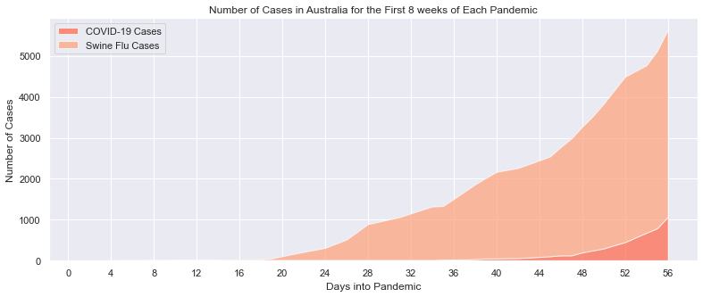

```python
# Ensuring the plot is displayed directly below the code cell that produced it:

%matplotlib inline

# importing libraries:

import pandas as pd                           # importing pandas library with structures and operations to manipulate data.

import numpy as np                            # manipulation of arrays.

import matplotlib.pyplot as plt               # importing matplotlib.pyplot for setting style and plot attributes.

import seaborn as sns                         # importing seaborn for statistical data visualisation.

sns.set()                                     # set seaborn style

# using Pandas to read in 1st csv file as 'covid_df', filtering raw data with required columns and parsing dates:

covid_df = pd.read_csv('owid-covid-data.csv', usecols=["date","location","total_cases"], parse_dates=['date'])

# using Pandas to read in 2nd csv file as 'swine_flu_df', filtering raw data with required columns and parsing dates:

swine_flu_df = pd.read_csv('data.csv', usecols=["Date","Country","Cumulative no. of cases"], parse_dates=['Date'])

# filtering the attribute 'location' so that 'covid_df' data frame only contains rows containing 'Australia'.

covid_df = covid_df.query('location == "Australia"')

# filtering the attribute 'Country' so that 'swine_flu_df' data frame only contains rows containing 'Australia'.

swine_flu_df = swine_flu_df.query("Country == 'Australia'")

# upon inspection we note that 'swine_flu_df' has 23 missing dates in the first 8 weeks of data.
# the dates in 'swine_flu_df' are NumPy 'datetime64' type which encodes the dates as 64-bit integers.

# converting to Pandas Date time object and setting format (this is to setup for the resample):

swine_flu_df['Date'] =  pd.to_datetime(swine_flu_df['Date'], format='%Y/%m/%d')

# setting the index of the df to Date:

swine_flu_df.set_index('Date', inplace=True)

# Adding missing dates and interpolates mean value from neighbouring rows. However it also creates NaN's for 'Country':

swine_flu_df= swine_flu_df.resample('D').interpolate().reset_index()

# The data frame now has NaNs in place of the country name where values have been imputed.

# This fills the NaN's with the most frequent value from the column 'Country':

swine_flu_df = swine_flu_df.fillna(swine_flu_df['Country'].value_counts().index[0])

# we now have consecutive days with interpolated case number values for the first 58 days that swine flu was in Australia
# (keeping in mind that the data in this set spans 58 days).

# Resetting the index of 'covid_df':

covid_df = covid_df.reset_index()

# Selecting the first 56 rows of 'covid_df':

covid_df = covid_df[:56]

# selecting the first 56 rows of 'swine_flu_df':

swine_flu_df = swine_flu_df[:56]

# we now have two data frames with the same number of rows.
# concatenating both data frames across axis 1:

joined_df = pd.concat([covid_df, swine_flu_df], axis = 1)

# renaming the existing data frames columns:

joined_df.rename(columns={'total_cases': 'COVID-19 Cases', 'Cumulative no. of cases': 'Swine Flu Cases'}, inplace=True)

# At this stage we now have corresponding values for the first 56 days of each pandemic in Australia.
# we can therefore remove locations and dates so that we are left with corresponding raw values for number of cases
# for each respective pandemic in ascending order:

# Select sub set of columns and assigning value to 'final_df':

final_df = (joined_df[['COVID-19 Cases','Swine Flu Cases']])

# Now we can plot:

# defining range for x:

x = range(1,57)

# defining data for y:

cases = [final_df['COVID-19 Cases'],final_df['Swine Flu Cases']]

plt.figure(figsize=(13,5))        # setting figure size.

# setting the tick values for the x-axis:

plt.xticks(np.arange(0,58, 4.0))

# Basic stacked area chart with labels and chosen colours:

plt.stackplot(x,cases, labels=['COVID-19 Cases','Swine Flu Cases'], colors = ['tomato', 'lightsalmon'], alpha = 0.7)

plt.legend(loc='upper left')      # setting legend with positioning.

plt.xlabel('Days into Pandemic')  # setting x-axis label.

plt.ylabel('Number of Cases')     # setting y-axis label.

plt.title('Number of Cases in Australia for the First 8 weeks of Each Pandemic')  # setting title of graph.

plt.show()                        # show the graph.
```

### 2. How do the total deaths between H1N1 (Swine Flu) and COVID-19 compare during the first 8 weeks after the first cases were detected in Australia?

Now we look at deaths in Australia for the same period of time. As before, this plot uses data from two different data sets:

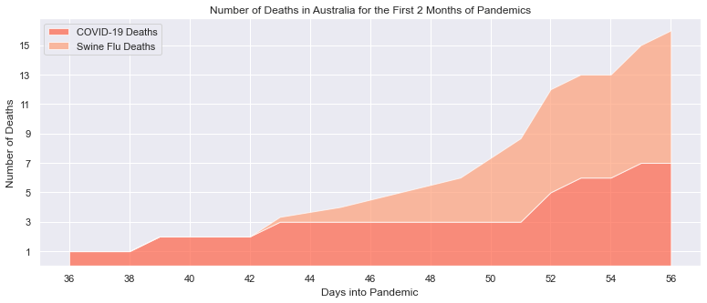

```python
# Ensuring the plot is displayed directly below the code cell that produced it:

%matplotlib inline

import pandas as pd                           # importing pandas library with structures and operations to manipulate data.

import numpy as np                            # manipulation of arrays.

import matplotlib.pyplot as plt               # importing matplotlib.pyplot for setting style and plot attributes.

import seaborn as sns                         # importing seaborn for statistical data visualisation.

sns.set()                                     # set seaborn style


# using Pandas to read in 1st csv file as 'covid_df', filtering data with required columns and parsing dates:

covid_df = pd.read_csv('owid-covid-data.csv', usecols=["date", "location", "total_deaths"], parse_dates=['date'])

# using Pandas to read in 2nd csv file as 'swine_flu_df', filtering raw data with required columns and parsing dates:

swine_flu_df = pd.read_csv('data.csv', usecols=["Date", "Country", "Cumulative no. of deaths"], parse_dates=['Date'])

# filtering attribute 'location' so that 'covid_df' data frame only contains rows containing 'Australia':

covid_df = covid_df.query('location == "Australia"')

# filtering attribute 'Country' so that 'swine_flu_df' data frame only contains rows containing 'Australia':

swine_flu_df = swine_flu_df.query("Country == 'Australia'")

# Upon inspection we note that swine_flu_df has 23 missing dates in the first two months of data.
# The dates are in NumPy 'datetime64' type which encodes the dates as 64-bit integers.

# Coverting to Pandas Date time object and setting format (this is to set up for resample):

swine_flu_df['Date'] =  pd.to_datetime(swine_flu_df['Date'], format='%Y/%m/%d')

# Setting the index of the df to Date:

swine_flu_df.set_index('Date', inplace=True)

# Adding missing dates and interpolates mean value from neighbouring rows. However this also creates NaN's for 'Country':

swine_flu_df= swine_flu_df.resample('D').interpolate().reset_index()

# This fills the NaN's with the most frequent value from the column 'Country':

swine_flu_df = swine_flu_df.fillna(swine_flu_df['Country'].value_counts().index[0])

# we now have consecutive days with interpolated death number values for the first 58 days that swine flu was in Australia.

# Resetting the index to 'covid_df':

covid_df = covid_df.reset_index()

# Selecting the first 56 rows:

covid_df = covid_df[:56]

# selecting the first 56 rows of 'swine_flu-df':

swine_flu_df = swine_flu_df[:56]

# Concatenating both data frames across axis 1:

joined_df = pd.concat([covid_df, swine_flu_df], axis = 1)

# Renaming the existing data frames columns:

joined_df.rename(columns={'total_deaths': 'COVID-19 Deaths', 'Cumulative no. of deaths': 'Swine Flu Deaths'}, inplace=True)

# At this stage we now have corresponding values for the first 56 days of each pandemic in Australia.
# we can therefore remove locations and dates so that we are left with corresponding raw values for number of cases
# for each respective pandemic in ascending order:

# Selecting required subset of columns:

final_df = (joined_df[['COVID-19 Deaths','Swine Flu Deaths']])

# Now we can plot:

# Defining range for x:

xx = range(1,57)

# Defining data for y:

deaths = [final_df['COVID-19 Deaths'],final_df['Swine Flu Deaths']]

plt.figure(figsize=(13,5))        # setting figure size.

# Setting the tick values to represent whole numbers (instead half numbers since values were interpolated):

plt.yticks(np.arange(1,18, 2.0))

# setting the tick values for the x-axis:

plt.xticks(np.arange(36,58, 2.0))

# Basic stacked area chart with baseline set to zero and with chosen colours:

plt.stackplot(xx, deaths, labels = ['COVID-19 Deaths','Swine Flu Deaths'], baseline = 'zero',
              colors = ['tomato', 'lightsalmon'],alpha = 0.7)

plt.legend(loc='upper left')       # setting legend with positioning.

plt.xlabel('Days into Pandemic')   # setting x-axis label.

plt.ylabel('Number of Deaths')     # setting y-axis label.

plt.title('Number of Deaths in Australia for the First 2 Months of Pandemics')  # Title of Graph:

plt.show()                         # plot graph.
```

Despite there being a larger number of overall deaths of Swine Flu compared to COVID-19 during the first 8 weeks in Australia, the number of COVID-19 deaths per case was greater than the number of Swine Flu deaths per case. Given this fact, it could be argued that a greater level of media attention to COVID-19 produced a heightened public awareness which may have had a limiting effect on death numbers as more people paid attention to mechanisms which avoided the spreading of the virus.

## 3. Is there a noticeable difference in COVID death rates between Countries?

This graph shows the change in death rate over time for Russia, Germany, Australia, United States, and New Zealand. The death rate was calculated by taking the quotient between the 'total number of deaths per million' and the 'total number of COVID-19 cases per million' for each respective country and thus creating a new variable 'death_rate'. The resultant output is a time series line plot with unique trajectories of death rate for each country.

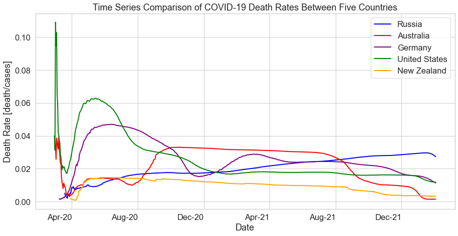

```python
# Ensuring the plot is displayed directly below the code cell that produced it:

%matplotlib inline

# libraries:

import pandas as pd                           # importing pandas library with structures and operations to manipulate data.

import numpy as np                            # manipulation of arrays.

import matplotlib.pyplot as plt               # importing matplotlib.pyplot for setting style and plot attributes.

import matplotlib.dates as mdates             # importing matplotlib.mdates for manipulation of date formatting.

import seaborn as sns                         # importing seaborn for statistical data visualisation.


sns.set(font_scale = 1.5, rc={"lines.linewidth": 2.0}, style = "whitegrid")  # Use white grid plot background from seaborn.

plt.figure(figsize = (15, 8))                     # setting figure size.

df_dict = {}                                      # defining empty dictionary 'df_dict'.

# importing csv as Pandas dataframe, filtering raw data with required columns and parsing dates:

dframe = pd.read_csv('owid-covid-data.csv', usecols=['date','location',
                    'total_deaths_per_million', 'total_cases_per_million'], parse_dates=['date'])


df_dict['filtered_df1'] = dframe.query('location == "Russia"')          # filtering attribute 'location' so that the key
                                                                        # 'filtered_df1' in 'df_dict' only contains values
                                                                        # for 'Russia'.

df_dict['filtered_df2'] = dframe.query('location == "Australia"')       # filtering attribute 'location' so that the key
                                                                        # 'filtered_df2' in 'df_dict' only contains values
                                                                        # for 'Australia'.

df_dict['filtered_df3'] = dframe.query('location == "Germany"')         # filtering attribute 'location' so that the key
                                                                        # 'filtered_df3' in 'df_dict' only contains values
                                                                        # for 'Germany'.


df_dict['filtered_df4'] = dframe.query('location == "United States"')   # filtering attribute 'location' so that the key
                                                                        # 'filtered_df4' in 'df_dict' only contains values
                                                                        # for 'United States'.


df_dict['filtered_df5'] = dframe.query('location == "New Zealand"')     # filtering attribute 'location' so that the key
                                                                        # 'filtered_df5' in 'df_dict' only contains values
                                                                        # for 'New Zealand'.


tdpm_dict = {}                                                          # defining empty dictionary 'tdpm_dict'.

tdpm_dict["tdpm"] = np.array([dframe.total_deaths_per_million])         # creating an array of the variable
                                                                        # 'total deaths per million'.

tcpm_dict = {}                                                          # defining empty dictionary 'tcpm_dict'.

tcpm_dict["tcpm"] = np.array([dframe.total_cases_per_million])          # creating an array of the variable
                                                                        # 'total cases per million'.

dr_dict = {}                                                            # defining empty dictionary 'dr_dict'.

dr_dict["death_rate"] = np.divide(tdpm_dict["tdpm"],tcpm_dict["tcpm"])  # taking the quotient of the
                                                                        # two variables to create the key
                                                                        # 'death rate' in 'dr_dict'.


dr_df_dict = {}                                                         # defining empty dictionary 'dr_df_dict'.

dr_df_dict["death_rate"] = pd.DataFrame(dr_dict["death_rate"])          # converting 'death rate'
                                                                        # array to data frame.

dr_df_trans_dict = {}                                                   # defining empty dictionary 'dr_df_tdict'.

dr_df_trans_dict["death_rate"] = dr_df_dict["death_rate"].transpose()   # transposing 'death rate'
                                                                        # data frame to make concatenation
                                                                        # possible.

dr_df_trans_dict["death_rate"].reset_index(drop=True, inplace=True)     # reset indexes to enable proper
                                                                        # concatenation for RHS data frame.

dframe.reset_index(drop=True, inplace=True)                             # reset indices to enable proper
                                                                        # concatenation for LHS data frame.


df_final_dict = {}                                                      # defining empty dictionary 'df_final_dict'.



for i in range(1,6):                                                    # creating a for loop.



    # select subset of columns for specific countries prior to concatenation:

    df_final_dict ["df%s"%i] = (df_dict["filtered_df%s" %i][['location', 'date']])

    # concatenating two data frames into one:

    df_final_dict ["df%s"%i] = pd.concat([df_final_dict["df%s"%i], dr_df_trans_dict["death_rate"]],
                                   axis=1, ignore_index = True)

    # rename column with relevant title:

    df_final_dict ["df%s"%i].rename(columns = {1:'Date'}, inplace = True)

    # rename column with relevant title:

    df_final_dict ["df%s"%i].rename(columns = {0:'Location'}, inplace = True)

    # rename column with relevant title:

    df_final_dict ["df%s"%i].rename(columns = {2:'Death Rate'}, inplace = True)

# Now we can set the parameters for the plot.

# gca() function used to get the current axes:

ax = plt.gca()

ax.set_title("Time Series Comparison of COVID-19 Death Rates Between Five Countries")   # plot title.

ax.set_xlabel("Date")                                                                   # x-axis label.

ax.set_ylabel("Death Rate [death/cases]")                                               # y-axis label.


# plot Russian specific data in blue:

df_final_dict ["df1"].plot(kind='line', x='Date',y='Death Rate', label = 'Russia', color = 'blue', ax=ax)

# plot Australian specific data in red:

df_final_dict ["df2"].plot(kind='line', x='Date', y='Death Rate', label = 'Australia', color = 'red', ax=ax)

# plot German specific data in purple:

df_final_dict ["df3"].plot(kind='line', x='Date', y='Death Rate', label = 'Germany', color = 'purple', ax=ax)

# plot United States specific data in green:

df_final_dict ["df4"].plot(kind='line', x='Date', y='Death Rate', label = 'United States', color = 'green', ax=ax)

# plot New Zealand specific data in orange:

df_final_dict ["df5"].plot(kind='line', x='Date', y='Death Rate', label = 'New Zealand', color = 'orange', ax=ax)



date_form = mdates.DateFormatter("%b-%y")      # format dates to display three letters of month then year.

ax.xaxis.set_major_formatter(date_form)        # specify the format of major ticks on x-axis.

four_mths = mdates.MonthLocator(interval=4)    # specify intervals between major ticks to four months.

ax.xaxis.set_major_locator(four_mths)          # set major x-axis ticks.

plt.xticks(rotation=0)                         # no rotation on x-axis labels

plt.show()                                     # show plot.
```

We can see the initial spike experienced by some nations as the virus began to spread. Also, the different trajectories of the death rate between the Countries may highlight differences in the way respective governments are dealing with the issue.

## 4. How do the percentages of vaccinated populations differ by Country?

Here we look at the total number of people who received all doses prescribed by the vaccination protocol per 100 people in the total population for ten different Countries. The columns used contain rolling cumulative values. As such, a function was used which returns the max value for each country.

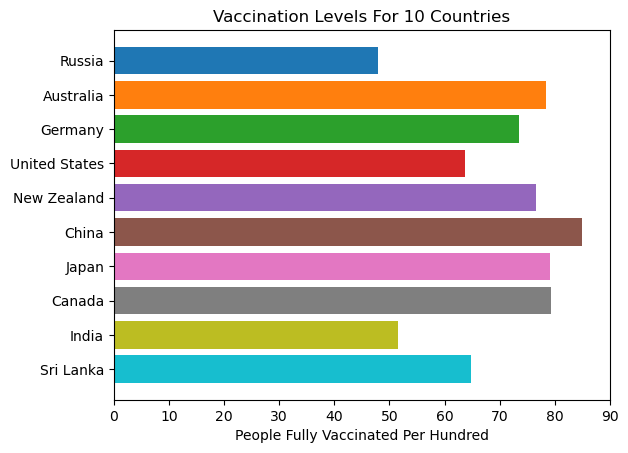

```python
# Ensuring the plot is displayed directly below the code cell that produced it:

%matplotlib inline

# libraries:

import pandas as pd                           # importing pandas library with structures and operations to manipulate data.

import numpy as np                            # manipulation of arrays.

import matplotlib.pyplot as plt               # setting style and plot attributes such as the range for x and y axes

import seaborn as sns                         # importing seaborn for statistical data visualisation.

sns.set()                                     # turn on seaborn styling

# importing csv as Pandas dataframe and filtering raw data with required columns:

dframe = pd.read_csv('owid-covid-data.csv', usecols=['location', 'people_fully_vaccinated_per_hundred'])


dframe = dframe.replace(0, np.nan)            # replace zeros with NaN

dframe = dframe.dropna()                      # drop all rows with Nan

loc = ['Russia', 'Australia', 'Germany', 'United States','New Zealand',
       'China', 'Japan', 'Canada', 'India', 'Sri Lanka']                # creating a list of country names and assigning
                                                                        # values to 'loc'.

filtered_df = dframe.query('location == "Russia"')               # filtering 'dframe' to values for 'Russia' and
                                                                 # assigning result to 'filtered_df'.

m1 = max(filtered_df['people_fully_vaccinated_per_hundred'])     # taking max value of 'filtered_df' and assigning to 'm1'.


filtered_df2 = dframe.query('location == "Australia"')           # filtering 'dframe' to values for 'Australia'
                                                                 # and assigning result to 'filtered_df2'.

m2 = max(filtered_df2['people_fully_vaccinated_per_hundred'])    # taking max value of 'filtered_df2' and assigning to 'm2'.


filtered_df3 = dframe.query('location == "Germany"')             # filtering 'dframe' to values for 'Germany'
                                                                 # and assigning result to 'filtered_df3'.

m3 = max(filtered_df3['people_fully_vaccinated_per_hundred'])    # taking max value of 'filtered_df3' and assigning to 'm3'.


filtered_df4 = dframe.query('location == "United States"')       # filtering 'dframe' to values for 'United States'
                                                                 # and assigning result to 'filtered_df4'.

m4 = max(filtered_df4['people_fully_vaccinated_per_hundred'])    # taking max value of 'filtered_df4' and assigning to 'm4'.


filtered_df5 = dframe.query('location == "New Zealand"')         # filtering 'dframe' to values for 'New Zealand'
                                                                 # and assigning result to 'filtered_df5'.

m5 = max(filtered_df5['people_fully_vaccinated_per_hundred'])    # taking max value of 'filtered_df5' and assigning to 'm5'.


filtered_df6 = dframe.query('location == "China"')               # filtering 'dframe' to values for 'China' and
                                                                 # assigning result to 'filtered_df6'.

m6 = max(filtered_df6['people_fully_vaccinated_per_hundred'])    # taking max value of 'filtered_df6' and assigning to 'm6'.


filtered_df7 = dframe.query('location == "Japan"')               # filtering 'dframe' to values for 'Japan' and
                                                                 # assigning result to 'filtered_df7'.

m7 = max(filtered_df7['people_fully_vaccinated_per_hundred'])    # taking max value of 'filtered_df7' and assigning to 'm7'.


filtered_df8 = dframe.query('location == "Canada"')              # filtering 'dframe' to values for 'Canada' and
                                                                 # assigning result to 'filtered_df8'.

m8 = max(filtered_df8['people_fully_vaccinated_per_hundred'])    # taking max value of 'filtered_df8' and assigning to 'm8'.


filtered_df9 = dframe.query('location == "India"')               # filtering 'dframe' to values for 'India' and
                                                                 # assigning result to 'filtered_df9'.

m9 = max(filtered_df9['people_fully_vaccinated_per_hundred'])    # taking max value of 'filtered_df9' and assigning to 'm9'.


filtered_df10 = dframe.query('location == "Sri Lanka"')          # filtering 'dframe' to values for 'Sri Lanka' and
                                                                 # assigning result to 'filtered_df10'.

m10 = max(filtered_df10['people_fully_vaccinated_per_hundred'])  # taking max value of 'filtered_df10' and
                                                                 # assigning to 'm10'.

vax = [m1,m2,m3,m4,m5,m6,m7,m8,m9,m10]                           # creating a list with max values and assigning to 'vax'.



# plotting results:

plt.rcdefaults()                                # used to restore the rc params from Matplotlib’s internal default style.

fig, ax = plt.subplots()                        # creating plot.

colour = sns.color_palette('tab10')          # defining colour palette.

plt.barh(loc, vax, align='center', color = (colour))   # defining plot type with parameters.

ax.set_yticks(loc)                                     # defining y-axis ticks.

ax.invert_yaxis()                                      # labels read top-to-bottom

ax.set_xlabel('People Fully Vaccinated Per Hundred')   # x-axis label.

ax.set_title('Vaccination Levels For 10 Countries')    # plot title.

plt.xlim(0,90)                                         # x-axis range.

plt.show()                                             # plot.
```

From the horizontal bar plot above, we can see that to date, Russia has not managed to reach 50% vaccination and that China has approximately 85% of their population vaccinated. We can also determine that Japan, Canada, and Australia have all achieved similar vaccination rates for their populations.

## 5. Is there a relationship between the median age of a population and the average reproduction rate of the SARS-CoV-2 Coronavirus?

Here we look at global data and compare all non-zero values for mean Coronavirus reproduction rates per country and plot against the respective median age of that country. The data points are then coloured by life expectancy to add an extra dimension to the plot. Average reproduction rates per location were computed through the use of the group_by() and mean() functions:

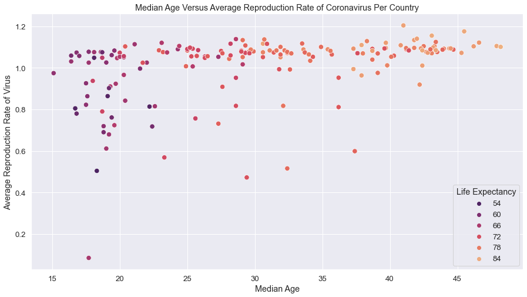

```python
# Ensuring the plot is displayed directly below the code cell that produced it:

%matplotlib inline

# libraries:

import pandas as pd                            # importing pandas library with structures and operations to manipulate data.

import numpy as np                             # import NumPy to assist with manipulation of data frames.

import matplotlib.pyplot as plt                # setting style and plot attributes such as the range for x and y axes

import seaborn as sns                          # importing seaborn for statistical data visualisation.

sns.set(font_scale = 1.2, style = "darkgrid")  # use dark grid plot background from seaborn.

# importing csv as Pandas dataframe, filtering raw data with required columns and parsing dates:

dframe = pd.read_csv('owid-covid-data.csv', usecols=['date','location','population', 'life_expectancy',
                            'reproduction_rate', 'median_age'], parse_dates=['date'])

grouped_df = dframe.groupby('location')        # grouping data frame by 'location' and assigning to variable 'grouped_df'.

mean = grouped_df.mean()                       # using the mean() function and assigning values to 'mean'.

mean = mean.replace(0, np.nan)                 # replacing zeros with NaN.

mean = mean.dropna()                           # drop all rows with NaN.

mean = mean.reset_index()                      # resetting the index.

plt.figure(figsize=(15,8))                     # specify size of plot.



ax = sns.scatterplot(data=mean, x= "median_age", y="reproduction_rate",
                     hue = 'life_expectancy',s = 70, palette = 'flare_r')   # Specify scatterplot with parameters.

ax = plt.gca()                                                              # gca() function used to get current axis.

ax.set_title("Median Age Versus Average Reproduction Rate of Coronavirus Per Country")  # set title of plot.

ax.set_xlabel("Median Age")                                                 # set x-axis label for plot.

ax.set_ylabel("Average Reproduction Rate of Virus")                         # set y-axis label for plot.

ax.get_legend().set_title("Life Expectancy")                                # set label for legend.

plt.show()                                                                  # show plot.
```

From the scatterplot we can see that the majority of the data points for the average reproduction rate of the virus tend to converge to values between 1 and 1.2. We can also see that the median age of a country is closely linked to its life expectancy.

## 6. How do certain Countries compare with new case numbers over the last 12 months?

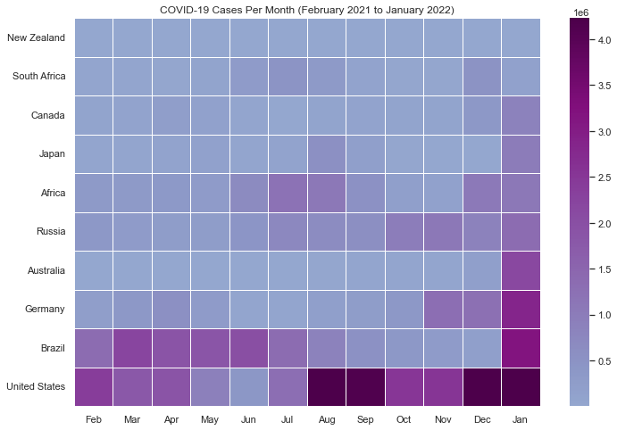

```python
# Ensuring the plot is displayed directly below the code cell that produced it:

%matplotlib inline

# libraries:

import pandas as pd                           # importing pandas library with structures and operations to manipulate data.

import numpy as np                            # manipulation of arrays.

import matplotlib.pyplot as plt               # setting style and plot attributes such as the range for x and y axes.

import seaborn as sns                         # importing seaborn for statistical data visualisation.

sns.set()                                     # turn on seaborn styling

# importing data as a panda data frame, filtering raw data with required columns and parsing dates:

dframe = pd.read_csv('owid-covid-data.csv', usecols=['location','date', 'new_cases'], parse_dates=['date'])

# Splitting dates to create two new columns in the data frame:

dframe['year'] = pd.DatetimeIndex(dframe['date']).year           # creating a column for 'year'.

dframe['month'] = pd.DatetimeIndex(dframe['date']).month         # creating a column for 'month'.

dframe = dframe.set_index('date')                                # setting index to 'date'.

# using a query to create sub sets of 'dframe' where each sub set data frame only holds values for a specific location:

rus_df = dframe.query('location == "Russia"')
aus_df = dframe.query('location == "Australia"')
ger_df = dframe.query('location == "Germany"')
usa_df = dframe.query('location == "United States"')
new_df = dframe.query('location == "New Zealand"')
sou_df = dframe.query('location == "South Africa"')
can_df = dframe.query('location == "Canada"')
jap_df = dframe.query('location == "Japan"')
afr_df = dframe.query('location == "Africa"')
bra_df = dframe.query('location == "Brazil"')

# Now we process the required data for each Country. We start with Russia:

rus_df21 = rus_df['2021-02-01' :'2021-12-31']                                                   # specifying date range for
                                                                                                # eleven months in 2021 and
                                                                                                # assigning to 'rus_df21'.

rus_new_cases21 = rus_df21.groupby('month').agg(qty =('new_cases', 'sum')).astype({'qty':int})  # grouping data by 'month'
                                                                                                # and summing values of
                                                                                                # 'new_cases', then assigning
                                                                                                # to 'rus_new_cases21'.

rus_df22 = rus_df['2022-01-01' :'2022-01-31']                                                   # specifying date range for
                                                                                                # one month in 2022 and
                                                                                                # assigning to 'rus_df22'.

rus_new_cases22 = rus_df22.groupby('month').agg(qty =('new_cases', 'sum')).astype({'qty':int})  # grouping data by 'month'
                                                                                                # and summing values of
                                                                                                # 'new_cases', then assigning
                                                                                                # to 'rus_new_cases22'.


rus_data = pd.concat([rus_new_cases21, rus_new_cases22], axis =0)                               # concatenating
                                                                                                # 'rus_new_cases21' with
                                                                                                # 'rus_new_cases22' and
                                                                                                # assigning to 'rus_data'
                                                                                                # so that data for Jan 2022
                                                                                                # comes after 2021 data.


rus_data = rus_data.rename(columns = {'qty':'Russia'})                                          # renaming the 'qty' column
                                                                                                # to name of the Country.


# This whole process is repeated for each respective country

# Australia:

aus_df21 = aus_df['2021-02-01' :'2021-12-31']
aus_new_cases21 = aus_df21.groupby('month').agg(qty =('new_cases', 'sum')).astype({'qty':int})
aus_df22 = aus_df['2022-01-01' :'2022-01-31']
aus_new_cases22 = aus_df22.groupby('month').agg(qty =('new_cases', 'sum')).astype({'qty':int})
aus_data = pd.concat([aus_new_cases21, aus_new_cases22], axis =0)
aus_data = aus_data.rename(columns = {'qty':'Australia'})

# Germany:

ger_df21 = ger_df['2021-02-01' :'2021-12-31']
ger_new_cases21 = ger_df21.groupby('month').agg(qty =('new_cases', 'sum')).astype({'qty':int})
ger_df22 = ger_df['2022-01-01' :'2022-01-31']
ger_new_cases22 = ger_df22.groupby('month').agg(qty =('new_cases', 'sum')).astype({'qty':int})
ger_data = pd.concat([ger_new_cases21, ger_new_cases22], axis =0)
ger_data = ger_data.rename(columns = {'qty':'Germany'})

# United States:

usa_df21 = usa_df['2021-02-01' :'2021-12-31']
usa_new_cases21 = usa_df21.groupby('month').agg(qty =('new_cases', 'sum')).astype({'qty':int})
usa_df22 = usa_df['2022-01-01' :'2022-01-31']
usa_new_cases22 = usa_df22.groupby('month').agg(qty =('new_cases', 'sum')).astype({'qty':int})
usa_data = pd.concat([usa_new_cases21, usa_new_cases22], axis =0)
usa_data = usa_data.rename(columns = {'qty':'United States'})

# New Zealand:

new_df21 = new_df['2021-02-01' :'2021-12-31']
new_new_cases21 = new_df21.groupby('month').agg(qty =('new_cases', 'sum')).astype({'qty':int})
new_df22 = new_df['2022-01-01' :'2022-01-31']
new_new_cases22 = new_df22.groupby('month').agg(qty =('new_cases', 'sum')).astype({'qty':int})
new_data = pd.concat([new_new_cases21, new_new_cases22], axis =0)
new_data = new_data.rename(columns = {'qty':'New Zealand'})

# South Africa:

sou_df21 = sou_df['2021-02-01' :'2021-12-31']
sou_new_cases21 = sou_df21.groupby('month').agg(qty =('new_cases', 'sum')).astype({'qty':int})
sou_df22 = sou_df['2022-01-01' :'2022-01-31']
sou_new_cases22 = sou_df22.groupby('month').agg(qty =('new_cases', 'sum')).astype({'qty':int})
sou_data = pd.concat([sou_new_cases21, sou_new_cases22], axis =0)
sou_data = sou_data.rename(columns = {'qty':'South Africa'})

# Canada:

can_df21 = can_df['2021-02-01' :'2021-12-31']
can_new_cases21 = can_df21.groupby('month').agg(qty =('new_cases', 'sum')).astype({'qty':int})
can_df22 = can_df['2022-01-01' :'2022-01-31']
can_new_cases22 = can_df22.groupby('month').agg(qty =('new_cases', 'sum')).astype({'qty':int})
can_data = pd.concat([can_new_cases21, can_new_cases22], axis =0)
can_data = can_data.rename(columns = {'qty':'Canada'})

# Japan:

jap_df21 = jap_df['2021-02-01' :'2021-12-31']
jap_new_cases21 = jap_df21.groupby('month').agg(qty =('new_cases', 'sum')).astype({'qty':int})
jap_df22 = jap_df['2022-01-01' :'2022-01-31']
jap_new_cases22 = jap_df22.groupby('month').agg(qty =('new_cases', 'sum')).astype({'qty':int})
jap_data = pd.concat([jap_new_cases21, jap_new_cases22], axis =0)
jap_data = jap_data.rename(columns = {'qty':'Japan'})

# Africa:

afr_df21 = afr_df['2021-02-01' :'2021-12-31']
afr_new_cases21 = afr_df21.groupby('month').agg(qty =('new_cases', 'sum')).astype({'qty':int})
afr_df22 = afr_df['2022-01-01' :'2022-01-31']
afr_new_cases22 = afr_df22.groupby('month').agg(qty =('new_cases', 'sum')).astype({'qty':int})
afr_data = pd.concat([afr_new_cases21, afr_new_cases22], axis =0)
afr_data = afr_data.rename(columns = {'qty':'Africa'})

# Brazil:

bra_df21 = bra_df['2021-02-01' :'2021-12-31']
bra_new_cases21 = bra_df21.groupby('month').agg(qty =('new_cases', 'sum')).astype({'qty':int})
bra_df22 = bra_df['2022-01-01' :'2022-01-31']
bra_new_cases22 = bra_df22.groupby('month').agg(qty =('new_cases', 'sum')).astype({'qty':int})
bra_data = pd.concat([bra_new_cases21, bra_new_cases22], axis =0)
bra_data = bra_data.rename(columns = {'qty':'Brazil'})

# Now we concatenate all the individual data frames for each Country into one data frame called 'final_df'

final_df = pd.concat([rus_data, aus_data, ger_data, usa_data, new_data, sou_data,
                      can_data, jap_data, afr_data, bra_data], axis = 1)

final_df.reset_index(drop=True, inplace=True)              # resetting the index.

final_df = final_df.transpose()                            # transposing the data frame.

# here we rename the indexes to represent months:

final_df.rename(columns = {0: 'Feb', 1: 'Mar', 2: 'Apr', 3: 'May', 4: 'Jun', 5: 'Jul',
                           6: 'Aug', 7:'Sep', 8:'Oct', 9:'Nov', 10:'Dec', 11:'Jan'}, inplace=True)


plt.figure(figsize=(12,8))                                 # specify figure size.

plt.title('COVID-19 Cases Per Month (February 2021 to January 2022)')  # specify title of plot.

# create heat map with parameters and sort by month of January in ascending order:

ax = sns.heatmap(final_df.sort_values(by=['Jan'],ascending=True), square = True,
                 cmap="BuPu",robust = True, linewidth = 0.5, center = 420000)

plt.show()                                                 # show plot.
```

From the heat map we can see that many of the countries displayed have experienced an increase in case numbers in January 2022. This is most likely due to the emergence of the Omicron variant which has been identified as being more contagious (therefore spreading quicker).  
It is important to acknowledge however that the numbers above are **total case numbers** so countries with a higher population will inevitably produce higher numbers. We can therefore look at the numbers per million in each population to get a better picture of how each country performs:

## 7. How do certain Countries compare when looking at cases per million population over the last 12 months?

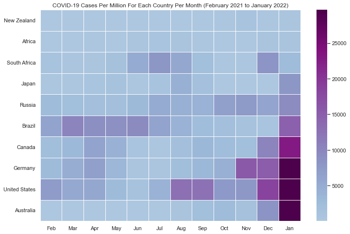

```python
# Ensuring the plot is displayed directly below the code cell that produced it:

%matplotlib inline

# libraries:

import pandas as pd                           # importing pandas library with structures and operations to manipulate data.

import numpy as np                            # manipulation of arrays.

import matplotlib.pyplot as plt               # setting style and plot attributes such as the range for x and y axes.

import seaborn as sns                         # importing seaborn for statistical data visualisation.

sns.set()                                     # turn on seaborn styling

# importing data as a panda data frame, filtering raw data with required columns and parsing dates:

dframe = pd.read_csv('owid-covid-data.csv', usecols=['location','date', 'new_cases_per_million'], parse_dates=['date'])

# Splitting dates to create two new columns in the data frame:

dframe['year'] = pd.DatetimeIndex(dframe['date']).year           # creating a column for 'year'.

dframe['month'] = pd.DatetimeIndex(dframe['date']).month         # creating a column for 'month'.

dframe = dframe.set_index('date')                                # setting index to 'date'.

# using a query to create sub sets of 'dframe' where each sub set data frame only holds values for a specific location:

rus_df = dframe.query('location == "Russia"')
aus_df = dframe.query('location == "Australia"')
ger_df = dframe.query('location == "Germany"')
usa_df = dframe.query('location == "United States"')
new_df = dframe.query('location == "New Zealand"')
sou_df = dframe.query('location == "South Africa"')
can_df = dframe.query('location == "Canada"')
jap_df = dframe.query('location == "Japan"')
afr_df = dframe.query('location == "Africa"')
bra_df = dframe.query('location == "Brazil"')

# Now we process the required data for each Country. We start with Russia.

# specifying date range for eleven months in 2021 and assigning to 'rus_df21':

rus_df21 = rus_df['2021-02-01' :'2021-12-31']

# grouping data by 'month' and summing values of 'new_cases_per_million', then assigning to 'rus_new_cases21':

rus_new_cases21 = rus_df21.groupby('month').agg(qty =('new_cases_per_million', 'sum')).astype({'qty':int})

# specifying date range for one month in 2022 and assigning to 'rus_df22':

rus_df22 = rus_df['2022-01-01' :'2022-01-31']

# grouping data by 'month' and summing values of 'new_cases', then assigning to 'rus_new_cases22':

rus_new_cases22 = rus_df22.groupby('month').agg(qty =('new_cases_per_million', 'sum')).astype({'qty':int})

# concatenating 'rus_new_cases21' with 'rus_new_cases22' and assigning to 'rus_data'
# so that data for Jan 2022 comes after 2021 data:

rus_data = pd.concat([rus_new_cases21, rus_new_cases22], axis =0)

# renaming the 'qty' column to name of the Country:

rus_data = rus_data.rename(columns = {'qty':'Russia'})

# we now repeat the process for each respective Country.

#Australia:

aus_df21 = aus_df['2021-02-01' :'2021-12-31']
aus_new_cases21 = aus_df21.groupby('month').agg(qty =('new_cases_per_million', 'sum')).astype({'qty':int})
aus_df22 = aus_df['2022-01-01' :'2022-01-31']
aus_new_cases22 = aus_df22.groupby('month').agg(qty =('new_cases_per_million', 'sum')).astype({'qty':int})
aus_data = pd.concat([aus_new_cases21, aus_new_cases22], axis =0)
aus_data = aus_data.rename(columns = {'qty':'Australia'})

# Germany

ger_df21 = ger_df['2021-02-01' :'2021-12-31']
ger_new_cases21 = ger_df21.groupby('month').agg(qty =('new_cases_per_million', 'sum')).astype({'qty':int})
ger_df22 = ger_df['2022-01-01' :'2022-01-31']
ger_new_cases22 = ger_df22.groupby('month').agg(qty =('new_cases_per_million', 'sum')).astype({'qty':int})
ger_data = pd.concat([ger_new_cases21, ger_new_cases22], axis =0)
ger_data = ger_data.rename(columns = {'qty':'Germany'})

# United States:

usa_df21 = usa_df['2021-02-01' :'2021-12-31']
usa_new_cases21 = usa_df21.groupby('month').agg(qty =('new_cases_per_million', 'sum')).astype({'qty':int})
usa_df22 = usa_df['2022-01-01' :'2022-01-31']
usa_new_cases22 = usa_df22.groupby('month').agg(qty =('new_cases_per_million', 'sum')).astype({'qty':int})
usa_data = pd.concat([usa_new_cases21, usa_new_cases22], axis =0)
usa_data = usa_data.rename(columns = {'qty':'United States'})

# New Zealand:

new_df21 = new_df['2021-02-01' :'2021-12-31']
new_new_cases21 = new_df21.groupby('month').agg(qty =('new_cases_per_million', 'sum')).astype({'qty':int})
new_df22 = new_df['2022-01-01' :'2022-01-31']
new_new_cases22 = new_df22.groupby('month').agg(qty =('new_cases_per_million', 'sum')).astype({'qty':int})
new_data = pd.concat([new_new_cases21, new_new_cases22], axis =0)
new_data = new_data.rename(columns = {'qty':'New Zealand'})

# South Africa:

sou_df21 = sou_df['2021-02-01' :'2021-12-31']
sou_new_cases21 = sou_df21.groupby('month').agg(qty =('new_cases_per_million', 'sum')).astype({'qty':int})
sou_df22 = sou_df['2022-01-01' :'2022-01-31']
sou_new_cases22 = sou_df22.groupby('month').agg(qty =('new_cases_per_million', 'sum')).astype({'qty':int})
sou_data = pd.concat([sou_new_cases21, sou_new_cases22], axis =0)
sou_data = sou_data.rename(columns = {'qty':'South Africa'})

# Canada:

can_df21 = can_df['2021-02-01' :'2021-12-31']
can_new_cases21 = can_df21.groupby('month').agg(qty =('new_cases_per_million', 'sum')).astype({'qty':int})
can_df22 = can_df['2022-01-01' :'2022-01-31']
can_new_cases22 = can_df22.groupby('month').agg(qty =('new_cases_per_million', 'sum')).astype({'qty':int})
can_data = pd.concat([can_new_cases21, can_new_cases22], axis =0)
can_data = can_data.rename(columns = {'qty':'Canada'})

# Japan:

jap_df21 = jap_df['2021-02-01' :'2021-12-31']
jap_new_cases21 = jap_df21.groupby('month').agg(qty =('new_cases_per_million', 'sum')).astype({'qty':int})
jap_df22 = jap_df['2022-01-01' :'2022-01-31']
jap_new_cases22 = jap_df22.groupby('month').agg(qty =('new_cases_per_million', 'sum')).astype({'qty':int})
jap_data = pd.concat([jap_new_cases21, jap_new_cases22], axis =0)
jap_data = jap_data.rename(columns = {'qty':'Japan'})

# Africa:

afr_df21 = afr_df['2021-02-01' :'2021-12-31']
afr_new_cases21 = afr_df21.groupby('month').agg(qty =('new_cases_per_million', 'sum')).astype({'qty':int})
afr_df22 = afr_df['2022-01-01' :'2022-01-31']
afr_new_cases22 = afr_df22.groupby('month').agg(qty =('new_cases_per_million', 'sum')).astype({'qty':int})
afr_data = pd.concat([afr_new_cases21, afr_new_cases22], axis =0)
afr_data = afr_data.rename(columns = {'qty':'Africa'})

# Brazil:

bra_df21 = bra_df['2021-02-01' :'2021-12-31']
bra_new_cases21 = bra_df21.groupby('month').agg(qty =('new_cases_per_million', 'sum')).astype({'qty':int})
bra_df22 = bra_df['2022-01-01' :'2022-01-31']
bra_new_cases22 = bra_df22.groupby('month').agg(qty =('new_cases_per_million', 'sum')).astype({'qty':int})
bra_data = pd.concat([bra_new_cases21, bra_new_cases22], axis =0)
bra_data = bra_data.rename(columns = {'qty':'Brazil'})

# Now we concatenate all the individual data frames for each Country into one data frame called 'final_df'

final_df = pd.concat([rus_data, aus_data, ger_data, usa_data, new_data, sou_data,
                      afr_data, jap_data, can_data, bra_data], axis = 1)


final_df.reset_index(drop=True, inplace=True)              # resetting the index.

final_df = final_df.transpose()                            # transposing the data frame.

# here we rename the indexes to represent months:

final_df.rename(columns = {0: 'Feb', 1: 'Mar', 2: 'Apr', 3: 'May', 4: 'Jun', 5: 'Jul',
                           6: 'Aug', 7:'Sep', 8:'Oct', 9:'Nov', 10:'Dec', 11:'Jan'}, inplace=True)

plt.figure(figsize=(12,8))                                 # specify figure size.

# plot title:

plt.title('COVID-19 Cases Per Million For Each Country Per Month (February 2021 to January 2022)')

# plot heatmap with parameters and sorting values by 'Jan' in ascending order:

ax = sns.heatmap(final_df.sort_values(by=['Jan'], ascending=True),
                 cmap="BuPu",robust = True, linewidth = 0.5, center = 8000)

plt.show()                                                  # show plot.
```

When looking at cases per million in each Country we see that in January 2022 Australia has experienced a proportionally larger amount of COVID-19 infections in the population compared to the other nations.

## 8. Over the last year, which months have been the most severe in terms of worldwide deaths?

In this visualisation we look at Global death numbers attributed to COVID-19 by aggregating monthly values and compare these totals as a percentage of the last 12 months via a Pie Chart:

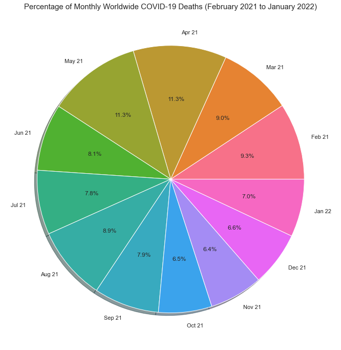

```python
# Ensuring the plot is displayed directly below the code cell that produced it:

%matplotlib inline

# libraries:

import pandas as pd                           # importing pandas library with structures and operations to manipulate data.

import matplotlib.pyplot as plt               # setting style and plot attributes such as the range for x and y axes.

import seaborn as sns                         # importing seaborn for statistical data visualisation.

sns.set()                                     # turn on seaborn styling

# importing data as a panda data frame, filtering raw data with required columns and parsing dates:

dframe = pd.read_csv('owid-covid-data.csv', usecols=['location', 'date', 'new_deaths'], parse_dates=['date'])

# Splitting dates to create two new columns in the data frame:

dframe['year'] = pd.DatetimeIndex(dframe['date']).year           # creating a column for 'year'.

dframe['month'] = pd.DatetimeIndex(dframe['date']).month         # creating a column for 'month'.

dframe = dframe.set_index('date')                                # setting index to 'date'.

dframe = dframe.query('location == "World"')                     # using query to select values for 'World'.

dframe21 = dframe['2021-02-01' :'2021-12-31']                    # selecting date range for dates in 2021 only and assigning
                                                                 # these values to 'dframe21'.

# grouping data in 'dframe21' by month, summing values, and assigning these to 'dframe_new_21':

dframe_new_21 = dframe21.groupby('month').agg(qty =('new_deaths', 'sum')).astype({'qty':int})

dframe22 = dframe['2022-01-01' :'2022-01-31']                    # selecting date range for dates in 2022 (i.e. January)
                                                                 # and assigning these value to 'dframe22'.

# grouping data in 'dframe22' by month, summing values, and assigning these to 'dframe_new_22':

dframe_new_22 = dframe22.groupby('month').agg(qty =('new_deaths', 'sum')).astype({'qty':int})

# concatenating 'dframe_new_21' with 'dframe_new_22' and assigning to 'dframe_world'
# to ensure correct order of monthly data:

dframe_world = pd.concat([dframe_new_21, dframe_new_22], axis =0)

# print(dframe_world) - this was used to check

df_list = dframe_world['qty'].tolist()                           # converting values in the data frame to a list
                                                                 # called 'df_list'.
# print(df_list) - this was used to check

colors = sns.color_palette("husl", 12)                           # define Seaborn color palette to use.

# creating a list called 'labels' so that the elemnts in the list can be used as labels in the pie chart:

labels = ['Feb 21', 'Mar 21', 'Apr 21', 'May 21', 'Jun 21', 'Jul 21', 'Aug 21', 'Sep 21',
          'Oct 21', 'Nov 21', 'Dec 21','Jan 22']

plt.figure(figsize=(12,12))                                      # specify figure size.

plt.title('Percentage of Monthly Worldwide COVID-19 Deaths (February 2021 to January 2022)', fontsize = 15)

plt.pie(df_list, labels = labels, shadow = True, colors = colors, autopct='%.1f%%')  #create pie chart.

plt.show()                                                       # show plot.
```

From the pie chart we can see that over the last year, the months with the most global deaths due to COVID-19 were April 2021 and May 2021. Also, November 2021 has seen the lowest percentage of global deaths in the last 12 months.

## 9. Is there a correlation between specific variables in the data set?

In this example we produce a correlation matrix to visualise correlation between the total number of deaths, the total number of cases, the reproduction rate of the virus, the number of ICU patients, the total number of boosters administered, the availability of handwashing facilities, the number of hospital beds per thousand, and life expectancy:

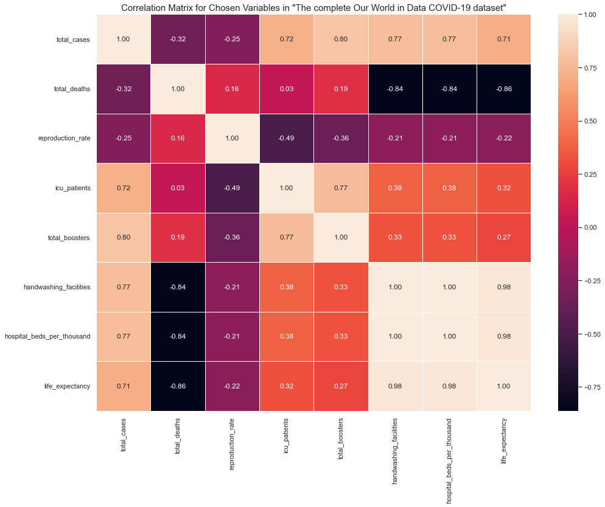

```python
# Ensuring the plot is displayed directly below the code cell that produced it:

%matplotlib inline

# libraries:

import pandas as pd                           # importing pandas library with structures and operations to manipulate data.

import matplotlib.pyplot as plt               # setting style and plot attributes such as the range for x and y axes.

import seaborn as sns                         # importing seaborn for statistical data visualisation.

sns.set()                                     # turn on seaborn styling

# importing data as a panda data frame and filtering raw data with required columns:

df = pd.read_csv('owid-covid-data.csv',usecols=['total_deaths', 'total_cases','reproduction_rate',
 'icu_patients','total_boosters','handwashing_facilities',
 'hospital_beds_per_thousand',
 'life_expectancy'])

# using the spearman correlation coefficient from the scipy statistics library:

from scipy.stats import spearmanr

# filtering the numeric columns (attributes) and using a for loop to iterate over all of the columns in the data
# so that if the item is numeric, its value will be stored in 'num_cols':

num_cols = [n for n,col in df.items() if pd.api.types.is_numeric_dtype(col)]

# obtaining the correlations between pairs within 'num_cols'. Here the dropna() function of Pandas Data Frame
# drops all of the missing values:

corr = spearmanr(df[num_cols].dropna()).correlation

plt.figure(figsize=(16,12))       # specifying the figure size.

# setting the x and y labels since corr only holds the values in an array:

sns.heatmap(corr, annot=True, fmt='.2f', linewidths=.5,
          xticklabels = num_cols, yticklabels = num_cols);

# setting title of plot:

plt.title(('Correlation Matrix for Chosen Variables in "The complete Our World in Data COVID-19 dataset"'),fontsize=15)

# show plot:

plt.show()
```

From the correlation matrix we can see perfect correlation between the number of handwashing facilities and the number of hospital beds per thousand. We also see a very high correlation between handwashing facilities and life expectancy, as well as hospital beds per thousand and life expectancy. Additionally, there is a high negative correlation between handwashing facilities, hospital beds per thousand, and life expectancy paired against the total number of deaths.

## 10. How does the reproduction rate of the virus differ per Continent?

In this example we create a boxplot to visually assess the spread of the distribution of the reproduction rate across all the continents.

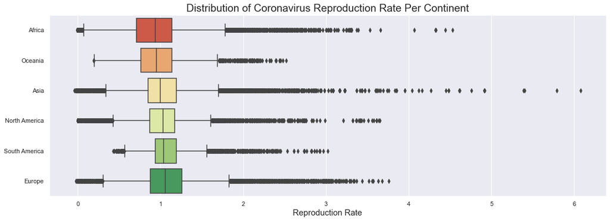

```python
# Ensuring the plot is displayed directly below the code cell that produced it:

%matplotlib inline

# libraries:

import pandas as pd                           # importing pandas library with structures and operations to manipulate data.

import matplotlib.pyplot as plt               # setting style and plot attributes such as the range for x and y axes.

import seaborn as sns                         # importing seaborn for statistical data visualisation.

sns.set()                                     # turn on seaborn styling.

# importing data as a panda data frame and filtering raw data with required columns:

df = pd.read_csv('owid-covid-data.csv',usecols=['continent','reproduction_rate'])

plt.figure(figsize=(18,6))                    # specifying the size of the plot.

# boxplot with parameters:

sns.boxplot(x = 'reproduction_rate', y = 'continent', data = df, palette = "RdYlGn", order = ["Africa","Oceania",
                                                                "Asia","North America","South America","Europe"])

# specifying the plot title and font size:

plt.title(('Distribution of Coronavirus Reproduction Rate Per Continent'),fontsize=19)

plt.xlabel('Reproduction Rate', fontsize = 15);  # setting x-axis label.

plt.ylabel('');     # setting y-axis label to show nothing along the margin since continents are given.

plt.show()          # show plot
```

From the boxplot we can ascertain the spread of distributions of the Coronavirus reproduction rates per continent where the boxes themselves show the interquartile range. We can see that the median reproduction rate for Europe is the highest of the continents. We also see a large amount of outliers for each continent.

## 11. How does the reproduction rate of the virus differ per Continent? (Alternative visualisation)

In this visualisation we use violin plots to look at the same data as above. This allows for more insight:

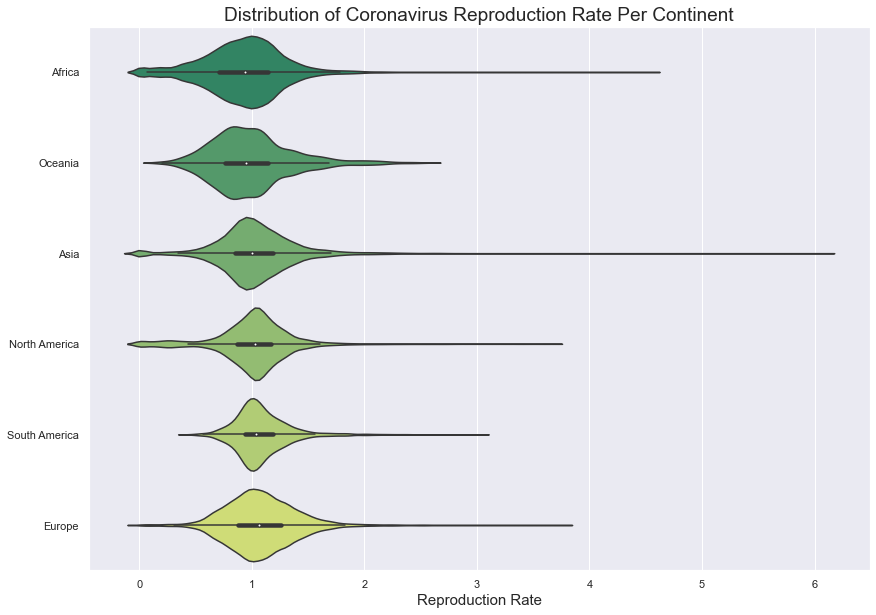

```python
# Ensuring the plot is displayed directly below the code cell that produced it:

%matplotlib inline

# libraries:

import pandas as pd                           # importing pandas library with structures and operations to manipulate data.

import matplotlib.pyplot as plt               # setting style and plot attributes such as the range for x and y axes.

import seaborn as sns                         # importing seaborn for statistical data visualisation.

sns.set()                                     # turn on seaborn styling.

# importing data as a panda data frame and filtering raw data with required columns:

df = pd.read_csv('owid-covid-data.csv',usecols=['continent','reproduction_rate'])

plt.figure(figsize=(14,10))                    # specifying the size of the plot.

# specifying the plot title and font size:

plt.title(('Distribution of Coronavirus Reproduction Rate Per Continent'),fontsize=19)

# violin plot just needs to know the columns you want represented and the data

sns.violinplot(x = 'reproduction_rate', y = 'continent', data = df, palette = "summer", scale = "width", order = ["Africa","Oceania",
                                                                "Asia","North America","South America","Europe"]);

plt.xlabel('Reproduction Rate', fontsize = 15);  # setting x-axis label.

plt.ylabel('');     # setting y-axis label to show nothing along the margin since continents are given.
```

Violin plots allow for a more intuitive visualisation due to their characteristics which feature a kernel density estimation of the underlying distribution. It should be acknowledged though that the scale has been set to 'width' so each violin in this plot has the same width. This means that smaller samples appear proportionally larger. Nevertheless, the shape in each violin is indicative of the density for each distribution. For example, we can see Africa, Asia, and North America have greater density in their distributions towards a reproduction rate near zero.

### References

[1] ABC/Reuters (29 January 2008). "Black death 'discriminated' between victims (ABC News in Science)". Australian Broadcasting Corporation. Archived from the original on 20 December 2016.

[2] https://www.cdc.gov/flu/pandemic-resources/2009-h1n1-pandemic.html Centers For Disease Control and Prevention, U.S. Department of Health & Human Services.